# Importing necessary libraries and train dataset

```python
import numpy as np
import pandas as pd
import seaborn as sns
import matplotlib.pyplot as plt
```

```python
df=pd.read_csv('Train-1617360447408-1660719685476.csv', na_values='?')
df.head()
```

|  | index | encounter_id | patient_id | race | gender | age | weight | time_in_hospital | medical_specialty | num_lab_procedures | ... | X19 | X20 | X21 | X22 | X23 | X24 | X25 | change | diabetesMed | readmitted |
| --- | --- | --- | --- | --- | --- | --- | --- | --- | --- | --- | --- | --- | --- | --- | --- | --- | --- | --- | --- | --- | --- |
| 0 | 69375 | 197029140 | 51521940 | Hispanic | Male | [80-90) | NaN | 4 | Emergency/Trauma | 39 | ... | No | No | No | No | No | No | No | No | Yes | 1 |
| 1 | 57272 | 163571946 | 92631357 | Caucasian | Male | [60-70) | NaN | 3 | Emergency/Trauma | 34 | ... | No | No | No | No | No | No | No | No | No | 0 |
| 2 | 82347 | 256497366 | 30023982 | Caucasian | Female | [50-60) | NaN | 6 | Nephrology | 50 | ... | No | Down | No | No | No | No | No | Ch | Yes | 1 |
| 3 | 89608 | 289891212 | 93606021 | AfricanAmerican | Female | [70-80) | NaN | 5 | NaN | 63 | ... | No | Down | No | No | No | No | No | Ch | Yes | 1 |
| 4 | 24091 | 81873900 | 23464296 | Caucasian | Male | [70-80) | NaN | 9 | Psychiatry | 17 | ... | No | No | No | No | No | No | No | No | No | 1 |

5 rows × 49 columns

### Checking the shape of the dataset

```python
df.shape
```

```
(66587, 49)
```

### Finding the unique values in the train data foe each of its columns

```python
df.nunique()
```

```
index                 48911
encounter_id          48911
patient_id            39650
race                      5
gender                    3
age                      10
weight                    9
time_in_hospital         14
medical_specialty        64
num_lab_procedures      113
num_procedures            7
num_medications          71
number_outpatient        33
number_emergency         26
number_inpatient         19
diag_1                  651
diag_2                  655
diag_3                  706
diag_4                  706
diag_5                48911
number_diagnoses         16
X1                        4
X2                        4
X3                        4
X4                        4
X5                        4
X6                        3
X7                        4
X8                        1
X9                        4
X10                       4
X11                       2
X12                       4
X13                       4
X14                       4
X15                       3
X16                       2
X17                       2
X18                       1
X19                       1
X20                       4
X21                       4
X22                       2
X23                       2
X24                       2
X25                       1
change                    2
diabetesMed               2
readmitted                2
dtype: int64
```

### Finding the number of null values for each column in train dataset

```python
df.isnull().sum()
```

```
index                     0
encounter_id              0
patient_id                0
race                   1504
gender                    0
age                       0
weight                64454
time_in_hospital          0
medical_specialty     32672
num_lab_procedures        0
num_procedures            0
num_medications           0
number_outpatient         0
number_emergency          0
number_inpatient          0
diag_1                   15
diag_2                  231
diag_3                  954
diag_4                  954
diag_5                    0
number_diagnoses          0
X1                        0
X2                        0
X3                        0
X4                        0
X5                        0
X6                        0
X7                        0
X8                        0
X9                        0
X10                       0
X11                       0
X12                       0
X13                       0
X14                       0
X15                       0
X16                       0
X17                       0
X18                       0
X19                       0
X20                       0
X21                       0
X22                       0
X23                       0
X24                       0
X25                       0
change                    0
diabetesMed               0
readmitted                0
dtype: int64
```

## Dropping the unnecessary columns

```python
df.drop('weight', axis=1, inplace=True)
```

We have dropped the column weight because it has more than 80% values missing, so definitely the readmission is not affected by weight.

```python
df.drop(['index', 'encounter_id','patient_id'], axis=1, inplace=True )
```

We have dropped index, encounter_id and patient_id because those are identification for patients and our target variable does not depend on identification.

```python
df.head()
```

|  | race | gender | age | time_in_hospital | medical_specialty | num_lab_procedures | num_procedures | num_medications | number_outpatient | number_emergency | ... | X19 | X20 | X21 | X22 | X23 | X24 | X25 | change | diabetesMed | readmitted |
| --- | --- | --- | --- | --- | --- | --- | --- | --- | --- | --- | --- | --- | --- | --- | --- | --- | --- | --- | --- | --- | --- |
| 0 | Hispanic | Male | [80-90) | 4 | Emergency/Trauma | 39 | 1 | 9 | 1 | 1 | ... | No | No | No | No | No | No | No | No | Yes | 1 |
| 1 | Caucasian | Male | [60-70) | 3 | Emergency/Trauma | 34 | 1 | 12 | 0 | 0 | ... | No | No | No | No | No | No | No | No | No | 0 |
| 2 | Caucasian | Female | [50-60) | 6 | Nephrology | 50 | 2 | 24 | 0 | 0 | ... | No | Down | No | No | No | No | No | Ch | Yes | 1 |
| 3 | AfricanAmerican | Female | [70-80) | 5 | NaN | 63 | 0 | 14 | 0 | 0 | ... | No | Down | No | No | No | No | No | Ch | Yes | 1 |
| 4 | Caucasian | Male | [70-80) | 9 | Psychiatry | 17 | 1 | 11 | 0 | 0 | ... | No | No | No | No | No | No | No | No | No | 1 |

5 rows × 45 columns

```python
df['race'].value_counts()
```

```
Caucasian          49906
AfricanAmerican    12406
Hispanic            1313
Other               1050
Asian                408
Name: race, dtype: int64
```

### Trying to find the value counts of the columns which have null values

```python
df['medical_specialty'].value_counts()
```

```
InternalMedicine                  9460
Emergency/Trauma                  4986
Family/GeneralPractice            4924
Cardiology                        3434
Surgery-General                   2067
                                  ...
Pediatrics-EmergencyMedicine         2
Proctology                           1
Pediatrics-Hematology-Oncology       1
Psychiatry-Addictive                 1
DCPTEAM                              1
Name: medical_specialty, Length: 64, dtype: int64
```

```python
df['diag_1'].value_counts()
```

```
428    4564
414    4183
786    2659
410    2382
486    2233
       ...
192       1
395       1
52        1
57        1
501       1
Name: diag_1, Length: 651, dtype: int64
```

```python
df['diag_2'].value_counts()
```

```
276     4420
428     4372
250     4100
427     3260
401     2371
        ...
192        1
460        1
V53        1
215        1
E882       1
Name: diag_2, Length: 655, dtype: int64
```

```python
df['diag_3'].value_counts()
```

```
250     7499
401     5479
276     3370
428     3025
427     2668
        ...
E815       1
E818       1
703        1
152        1
V22        1
Name: diag_3, Length: 706, dtype: int64
```

```python
df['diag_4'].value_counts()
```

```
250     7499
401     5479
276     3370
428     3025
427     2668
        ...
E815       1
E818       1
703        1
152        1
V22        1
Name: diag_4, Length: 706, dtype: int64
```

```python
df.dtypes
```

```
race                   object
gender                 object
age                    object
time_in_hospital        int64
medical_specialty      object
num_lab_procedures      int64
num_procedures          int64
num_medications         int64
number_outpatient       int64
number_emergency        int64
number_inpatient        int64
diag_1                 object
diag_2                 object
diag_3                 object
diag_4                 object
diag_5                float64
number_diagnoses        int64
X1                     object
X2                     object
X3                     object
X4                     object
X5                     object
X6                     object
X7                     object
X8                     object
X9                     object
X10                    object
X11                    object
X12                    object
X13                    object
X14                    object
X15                    object
X16                    object
X17                    object
X18                    object
X19                    object
X20                    object
X21                    object
X22                    object
X23                    object
X24                    object
X25                    object
change                 object
diabetesMed            object
readmitted              int64
dtype: object
```

### Finding the percentage of null values in each column

```python
df.isnull().sum()*100/len(df)
```

```
race                   2.258699
gender                 0.000000
age                    0.000000
time_in_hospital       0.000000
medical_specialty     49.066635
num_lab_procedures     0.000000
num_procedures         0.000000
num_medications        0.000000
number_outpatient      0.000000
number_emergency       0.000000
number_inpatient       0.000000
diag_1                 0.022527
diag_2                 0.346915
diag_3                 1.432712
diag_4                 1.432712
diag_5                 0.000000
number_diagnoses       0.000000
X1                     0.000000
X2                     0.000000
X3                     0.000000
X4                     0.000000
X5                     0.000000
X6                     0.000000
X7                     0.000000
X8                     0.000000
X9                     0.000000
X10                    0.000000
X11                    0.000000
X12                    0.000000
X13                    0.000000
X14                    0.000000
X15                    0.000000
X16                    0.000000
X17                    0.000000
X18                    0.000000
X19                    0.000000
X20                    0.000000
X21                    0.000000
X22                    0.000000
X23                    0.000000
X24                    0.000000
X25                    0.000000
change                 0.000000
diabetesMed            0.000000
readmitted             0.000000
dtype: float64
```

# Plotting a count plot for the target variable

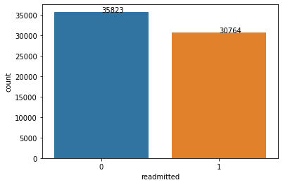

```python
y_count=sns.countplot(x='readmitted',data=df)
# Shows the count of observations in each categorical bin using bars

for p in y_count.patches:
    height = p.get_height()
    # Add text to the axes
    y_count.text(p.get_x()+p.get_width()/2, height + 1, height)
# The y_count.text method takes an x position, a y position and a string
```

From the count plot we are able to draw the conclusion that there is no class imbalance

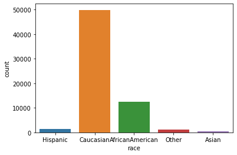

```python
y_count=sns.countplot(x='race',data=df)
```

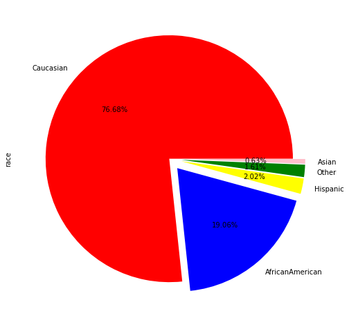

```python
explode=[0,0.1,0.1,0.1,0.1]
plt.figure(figsize=(8,10))
df['race'].value_counts().plot(kind='pie',autopct='%.2f%%',explode=explode,colors = ['red','blue','Yellow','Green','pink'])
plt.show()
```

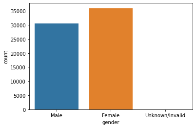

```python
y_count=sns.countplot(x='gender',data=df)
```

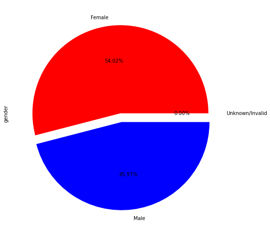

```python
explode=[0,0.1,0.1]
plt.figure(figsize=(8,10))
df['gender'].value_counts().plot(kind='pie',autopct='%.2f%%',explode=explode,colors = ['red','blue','Yellow'])
plt.show()
```

[figure not shown]

```python
sns.set(rc = {'figure.figsize':(15,12)})
sns.heatmap(df.corr(), cmap="YlGnBu", linewidths=0.1, annot=True, annot_kws={"fontsize":8})
plt.show()
```

### Converting the preliminary diagnostic test results from object to numeric

```python
df['diag_1']=pd.to_numeric(df.diag_1,errors='coerce')
```

```python
df['diag_2']=pd.to_numeric(df.diag_2,errors='coerce')
```

```python
df['diag_3']=pd.to_numeric(df.diag_3,errors='coerce')
```

```python
df['diag_4']=pd.to_numeric(df.diag_4,errors='coerce')
```

```python
df.dtypes
```

```
race                   object
gender                 object
age                    object
time_in_hospital        int64
medical_specialty      object
num_lab_procedures      int64
num_procedures          int64
num_medications         int64
number_outpatient       int64
number_emergency        int64
number_inpatient        int64
diag_1                float64
diag_2                float64
diag_3                float64
diag_4                float64
diag_5                float64
number_diagnoses        int64
X1                     object
X2                     object
X3                     object
X4                     object
X5                     object
X6                     object
X7                     object
X8                     object
X9                     object
X10                    object
X11                    object
X12                    object
X13                    object
X14                    object
X15                    object
X16                    object
X17                    object
X18                    object
X19                    object
X20                    object
X21                    object
X22                    object
X23                    object
X24                    object
X25                    object
change                 object
diabetesMed            object
readmitted              int64
dtype: object
```

## Splitting the data into x and y and also for training the model and testing the efficiency of the model

```python
# Train Test Split
X = df.drop('readmitted',axis='columns')
y = df['readmitted']

from sklearn.model_selection import train_test_split
X_train, X_test, y_train, y_test = train_test_split(X,y,test_size=0.2,random_state=5)
```

## Separating the columns which have categorical data and numerical data

```python
cat_cols=['race', 'gender', 'age', 'medical_specialty',  'X1', 'X2',
       'X3', 'X4', 'X5', 'X6', 'X7', 'X8', 'X9', 'X10', 'X11', 'X12', 'X13',
       'X14', 'X15', 'X16', 'X17', 'X18', 'X19', 'X20', 'X21', 'X22', 'X23',
       'X24', 'X25', 'change', 'diabetesMed']
```

```python
num_cols=['time_in_hospital', 'num_lab_procedures', 'num_procedures', 'num_medications',
       'number_outpatient', 'number_emergency', 'number_inpatient', 'diag_1',
       'diag_2', 'diag_3', 'diag_4', 'diag_5']
```

### Storing the test and train values in separate variables

```python
df_cat_train = X_train[cat_cols]
df_cat_test = X_test[cat_cols]
```

```python
df_num_train = X_train[num_cols]
df_num_test = X_test[num_cols]
```

## Importing simple imputer and using the mode for imputing categorical columns

```python
from sklearn.impute import SimpleImputer
imputer1 = SimpleImputer(strategy = 'most_frequent')
```

```python
imputer1.fit(df_cat_train)
```

```
SimpleImputer(strategy='most_frequent')
```

```python
X_train1 = pd.DataFrame(imputer1.transform(df_cat_train), columns=cat_cols)
X_test1 = pd.DataFrame(imputer1.transform(df_cat_test), columns=cat_cols)
```

## For numerical columns we use mean to impute null values

```python
imputer2 = SimpleImputer(strategy = 'mean')
imputer2.fit(df_num_train)
```

```
SimpleImputer()
```

```python
X_train_num = pd.DataFrame(imputer2.transform(df_num_train), columns=num_cols)
X_test_num = pd.DataFrame(imputer2.transform(df_num_test), columns=num_cols)
```

```python
X_train_num.columns
```

```
Index(['time_in_hospital', 'num_lab_procedures', 'num_procedures',
       'num_medications', 'number_outpatient', 'number_emergency',
       'number_inpatient', 'diag_1', 'diag_2', 'diag_3', 'diag_4', 'diag_5'],
      dtype='object')
```

```python
X_train1.columns
```

```
Index(['race', 'gender', 'age', 'medical_specialty', 'X1', 'X2', 'X3', 'X4',
       'X5', 'X6', 'X7', 'X8', 'X9', 'X10', 'X11', 'X12', 'X13', 'X14', 'X15',
       'X16', 'X17', 'X18', 'X19', 'X20', 'X21', 'X22', 'X23', 'X24', 'X25',
       'change', 'diabetesMed'],
      dtype='object')
```

## Concatenating the imputed columns into dataframes

```python
# Combine numeric and categorical in train
X_train = pd.concat([X_train1, X_train_num], axis = 1)

# Combine numeric and categorical in test
X_test = pd.concat([X_test1, X_test_num], axis = 1)
```

### Checking whether all the null values have been removed

```python
X_train.isnull().sum()
```

```
race                  0
gender                0
age                   0
medical_specialty     0
X1                    0
X2                    0
X3                    0
X4                    0
X5                    0
X6                    0
X7                    0
X8                    0
X9                    0
X10                   0
X11                   0
X12                   0
X13                   0
X14                   0
X15                   0
X16                   0
X17                   0
X18                   0
X19                   0
X20                   0
X21                   0
X22                   0
X23                   0
X24                   0
X25                   0
change                0
diabetesMed           0
time_in_hospital      0
num_lab_procedures    0
num_procedures        0
num_medications       0
number_outpatient     0
number_emergency      0
number_inpatient      0
diag_1                0
diag_2                0
diag_3                0
diag_4                0
diag_5                0
dtype: int64
```

```python
X_test.isnull().sum()
```

```
race                  0
gender                0
age                   0
medical_specialty     0
X1                    0
X2                    0
X3                    0
X4                    0
X5                    0
X6                    0
X7                    0
X8                    0
X9                    0
X10                   0
X11                   0
X12                   0
X13                   0
X14                   0
X15                   0
X16                   0
X17                   0
X18                   0
X19                   0
X20                   0
X21                   0
X22                   0
X23                   0
X24                   0
X25                   0
change                0
diabetesMed           0
time_in_hospital      0
num_lab_procedures    0
num_procedures        0
num_medications       0
number_outpatient     0
number_emergency      0
number_inpatient      0
diag_1                0
diag_2                0
diag_3                0
diag_4                0
diag_5                0
dtype: int64
```

```python
df.columns
```

```
Index(['race', 'gender', 'age', 'time_in_hospital', 'medical_specialty',
       'num_lab_procedures', 'num_procedures', 'num_medications',
       'number_outpatient', 'number_emergency', 'number_inpatient', 'diag_1',
       'diag_2', 'diag_3', 'diag_4', 'diag_5', 'number_diagnoses', 'X1', 'X2',
       'X3', 'X4', 'X5', 'X6', 'X7', 'X8', 'X9', 'X10', 'X11', 'X12', 'X13',
       'X14', 'X15', 'X16', 'X17', 'X18', 'X19', 'X20', 'X21', 'X22', 'X23',
       'X24', 'X25', 'change', 'diabetesMed', 'readmitted'],
      dtype='object')
```

## Applying label encoding to categorical columns for both X_train and X_test

```python
from sklearn.preprocessing import LabelEncoder

le=LabelEncoder()

for col in X_train.columns:
    if X_train[col].dtypes == 'object':
        X_train[col] = le.fit_transform(X_train[col])
```

```python
for col in X_test.columns:
    if X_test[col].dtypes == 'object':
        X_test[col] = le.fit_transform(X_test[col])
```

## Checking the shapes of X_train, X_test, y_train and y_test

```python
X_train.shape
```

```
(53269, 43)
```

```python
X_test.shape
```

```
(13318, 43)
```

```python
y_train.shape
```

```
(53269,)
```

```python
y_test.shape
```

```
(13318,)
```

```python
#df.diag_1 = pd.to_numeric(df.diag_1)
```

## Applying Standard Scaler on train and test data

```python
from sklearn.preprocessing import StandardScaler
scaler = StandardScaler()

scaler.fit(X_train)
```

```
StandardScaler()
```

```python
# scaling on train
X_train = scaler.transform(X_train)

# scaling on test
X_test = scaler.transform(X_test)
```

# Importing the test dataset

```python
test = pd.read_csv('test-1617360461595-1660719701431.csv',  na_values='?')
test.head()
```

|  | index | encounter_id | patient_id | race | gender | age | weight | time_in_hospital | medical_specialty | num_lab_procedures | ... | X18 | X19 | X20 | X21 | X22 | X23 | X24 | X25 | change | diabetesMed |
| --- | --- | --- | --- | --- | --- | --- | --- | --- | --- | --- | --- | --- | --- | --- | --- | --- | --- | --- | --- | --- | --- |
| 0 | 11128 | 46325466 | 3928383 | Caucasian | Female | [70-80) | NaN | 3 | NaN | 45 | ... | No | No | No | No | No | No | No | No | No | Yes |
| 1 | 79758 | 245219616 | 60926103 | Caucasian | Male | [60-70) | NaN | 2 | NaN | 10 | ... | No | No | No | No | No | No | No | No | No | Yes |
| 2 | 52497 | 155321232 | 25234848 | AfricanAmerican | Male | [70-80) | NaN | 11 | InternalMedicine | 41 | ... | No | No | Steady | No | No | No | No | No | No | Yes |
| 3 | 64504 | 179491944 | 86935374 | Caucasian | Female | [70-80) | NaN | 1 | InternalMedicine | 71 | ... | No | No | No | No | No | No | No | No | No | No |
| 4 | 987 | 7425954 | 2486826 | AfricanAmerican | Female | [50-60) | NaN | 7 | InternalMedicine | 59 | ... | No | No | Steady | No | No | No | No | No | Ch | Yes |

5 rows × 48 columns

## Dropping the columns that were dropped in train dataset

```python
test1=test.drop(['weight','index', 'encounter_id','patient_id'], axis=1)
```

### Converting the preliminary diagnostic test results from object to numeric

```python
test1['diag_1']=pd.to_numeric(test1.diag_1,errors='coerce')
test1['diag_2']=pd.to_numeric(test1.diag_2,errors='coerce')
test1['diag_3']=pd.to_numeric(test1.diag_3,errors='coerce')
test1['diag_4']=pd.to_numeric(test1.diag_4,errors='coerce')
```

### Storing the test and train values in separate variables

```python
cat_test = test1[cat_cols]
num_test = test1[num_cols]
```

## Using the mode for imputing categorical columns

```python
imputer11 = SimpleImputer(strategy = 'most_frequent')
```

```python
imputer11.fit(cat_test)
```

```
SimpleImputer(strategy='most_frequent')
```

```python
test_cat = pd.DataFrame(imputer1.transform(cat_test), columns=cat_cols)
```

## For numerical columns we use mean to impute null values

```python
imputer12 = SimpleImputer(strategy = 'mean')
```

```python
imputer12.fit(num_test)
```

```
SimpleImputer()
```

```python
test_num = pd.DataFrame(imputer12.transform(num_test), columns=num_cols)
```

## Concatenating the imputed columns into dataframes

```python
# Combine numeric and categorical in train
test1 = pd.concat([test_cat, test_num], axis = 1)
```

### Checking whether all the null values have been removed

```python
test1.isnull().sum()
```

```
race                  0
gender                0
age                   0
medical_specialty     0
X1                    0
X2                    0
X3                    0
X4                    0
X5                    0
X6                    0
X7                    0
X8                    0
X9                    0
X10                   0
X11                   0
X12                   0
X13                   0
X14                   0
X15                   0
X16                   0
X17                   0
X18                   0
X19                   0
X20                   0
X21                   0
X22                   0
X23                   0
X24                   0
X25                   0
change                0
diabetesMed           0
time_in_hospital      0
num_lab_procedures    0
num_procedures        0
num_medications       0
number_outpatient     0
number_emergency      0
number_inpatient      0
diag_1                0
diag_2                0
diag_3                0
diag_4                0
diag_5                0
dtype: int64
```

## Checking if the number of rows in X_train and test1 are same

```python
X_train.shape
```

```
(53269, 43)
```

```python
test1.shape
```

```
(16647, 43)
```

## Applying label encoding to test dataset

```python
for col in test1.columns:
    if test1[col].dtypes == 'object':
        test1[col] = le.fit_transform(test1[col])
```

## Importing logistic Regression and fitting the model

```python
# Fitting Logistic Regression to the Training set
from sklearn.linear_model import LogisticRegression
classifier = LogisticRegression(random_state = 0)
classifier.fit(X_train, y_train)
```

```
LogisticRegression(random_state=0)
```

## Predicting for Y_test and comparing it. Also checking accuracy

```python
ypred = classifier.predict(X_test)
score_logreg = classifier.score(X_test,y_test)
acc_log = round(score_logreg * 100, 2)
print("The accuracy of logistic regression model is:",round(acc_log,2,), "%")
```

```
The accuracy of logistic regression model is: 61.2 %
```

## Importing f1_score and confusion matrix and checking them for logistic regression

```python
from sklearn.metrics import confusion_matrix
from sklearn.metrics import f1_score
```

```python
f1_score(y_test, ypred)
```

```
0.41125541125541126
```

```python
cm = confusion_matrix(y_test, ypred)
cm
```

```
array([[6345,  853],
       [4315, 1805]], dtype=int64)
```

## Predicting the logistic regression values for test dataset

```python
y_test_log=classifier.predict(test1)
y_test_log
```

```
C:\Users\Apoorva Turup\anaconda3\lib\site-packages\sklearn\base.py:443: UserWarning: X has feature names, but LogisticRegression was fitted without feature names
  warnings.warn(
```

```
array([0, 0, 0, ..., 0, 0, 0], dtype=int64)
```

## Reading the sample submission file and dropping prediction column

```python
submission = pd.read_csv('Sample_submission-1617360730255-1660719714632.csv')
```

```python
submission.drop('prediction', axis=1, inplace=True)
```

## Adding our prediction to the submission dataframe anf converting it to .csv

```python
submission3 = pd.DataFrame({
        "encounter_id": submission["encounter_id"],
        "predicted": y_test_log
    })
submission3.to_csv('submission3.csv', index=False)
```

## Importing decision tree and knn classifier

```python
from sklearn.neighbors import KNeighborsClassifier
from sklearn.tree import DecisionTreeClassifier
```

## Fitting decision tree model and checking the metrics

```python
#decision tree
dec=DecisionTreeClassifier(random_state=0)
dec.fit(X_train,y_train)
Y_pred=dec.predict(X_test)
score=dec.score(X_test,y_test)
acc_dec = round(score * 100, 2)
print("The accuracy of decision tree model is:",round(acc_dec,2,), "%")
```

```
The accuracy of decision tree model is: 70.77 %
```

```python
f1_score(y_test, Y_pred)
```

```
0.6838300982701211
```

```python
cm = confusion_matrix(y_test, Y_pred)
cm
```

```
array([[5215, 1983],
       [1910, 4210]], dtype=int64)
```

## Predicting test dataset values using decision tree

```python
y_test_dec=dec.predict(test1)
y_test_dec
```

```
C:\Users\Apoorva Turup\anaconda3\lib\site-packages\sklearn\base.py:443: UserWarning: X has feature names, but DecisionTreeClassifier was fitted without feature names
  warnings.warn(
```

```
array([1, 0, 1, ..., 1, 1, 0], dtype=int64)
```

## Adding our prediction to the submission dataframe anf converting it to .csv

```python
submission4 = pd.DataFrame({
        "encounter_id": submission["encounter_id"],
        "predicted": y_test_dec
    })
submission4.to_csv('submission_dec.csv', index=False)
```

## Fitting KNN model and checking the metrics

```python
# KNN
knn = KNeighborsClassifier(n_neighbors = 3)
knn1=knn.fit(X_train, y_train)

Ypred = knn1.predict(X_test)

acc_knn = round(knn.score(X_train, y_train) * 100, 2)
print("The accuracy of knn model is:",round(acc_knn,2,), "%")
```

```
The accuracy of knn model is: 82.9 %
```

```python
f1_score(y_test, Ypred)
```

```
0.6297268096928539
```

```python
cm = confusion_matrix(y_test, Ypred)
cm
```

```
array([[   1, 7197],
       [   0, 6120]], dtype=int64)
```

```python
y_test_knn=knn1.predict(test1)
y_test_knn
```

```
C:\Users\Apoorva Turup\anaconda3\lib\site-packages\sklearn\base.py:443: UserWarning: X has feature names, but KNeighborsClassifier was fitted without feature names
  warnings.warn(
```

```
array([1, 1, 1, ..., 1, 1, 1], dtype=int64)
```

## Adding our prediction to the submission dataframe anf converting it to .csv

```python
submission5 = pd.DataFrame({
        "encounter_id": submission["encounter_id"],
        "predicted": y_test_knn
    })
submission5.to_csv('submission_knn.csv', index=False)
```

## Fitting SVM model and checking the metrics

```python
from sklearn.svm import SVC
sv=SVC(gamma='auto')
sv.fit(X_train,y_train)
yp=sv.predict(X_test)
score=sv.score(X_test,y_test)
acc_svr = round(sv.score(X_train, y_train) * 100, 2)
print("The accuracy of SVM model is:",round(acc_svr,2,), "%")
```

```
The accuracy of SVM model is: 66.27 %
```

```python
from sklearn.metrics import classification_report
```

```python
f1_score(y_test, yp)
```

```
0.011022856216566705
```

```python
print(classification_report(yp,y_test))
```

```
              precision    recall  f1-score   support

           0       1.00      0.54      0.70     13269
           1       0.01      0.69      0.01        49

    accuracy                           0.54     13318
   macro avg       0.50      0.62      0.36     13318
weighted avg       0.99      0.54      0.70     13318
```

## Predicting test dataset values using SVM

```python
y_test_svm=sv.predict(test1)
y_test_svm
```

```
C:\Users\Apoorva Turup\anaconda3\lib\site-packages\sklearn\base.py:443: UserWarning: X has feature names, but SVC was fitted without feature names
  warnings.warn(
```

```
array([0, 0, 0, ..., 0, 0, 0], dtype=int64)
```

## Adding our prediction to the submission dataframe and converting it to .csv

```python
submission6 = pd.DataFrame({
        "encounter_id": submission["encounter_id"],
        "predicted": y_test_knn
    })
submission6.to_csv('submission_svm.csv', index=False)
```

## Importing random forest and fitting the model

```python
from sklearn.ensemble import RandomForestClassifier
```

```python
# Random Forest

random_forest = RandomForestClassifier(n_estimators=100)
random_forest.fit(X_train, y_train)

Y_prediction = random_forest.predict(X_test)

random_forest.score(X_train, y_train)
acc_random_forest = round(random_forest.score(X_train, y_train) * 100, 2)
print(round(acc_random_forest,2,), "%")
```

```
100.0 %
```

```python
f1_score(y_test, Y_prediction)
```

```
0.7369240079536612
```

```python
y_test_random_forest=sv.predict(test1)
y_test_random_forest
```

```
C:\Users\Apoorva Turup\anaconda3\lib\site-packages\sklearn\base.py:443: UserWarning: X has feature names, but SVC was fitted without feature names
  warnings.warn(
```

```
array([0, 0, 0, ..., 0, 0, 0], dtype=int64)
```

## Adding our prediction to the submission dataframe and converting it to .csv

```python
submission7 = pd.DataFrame({
        "encounter_id": submission["encounter_id"],
        "predicted": y_test_random_forest
    })
submission7.to_csv('submission_rf.csv', index=False)
```

```python
results = pd.DataFrame({
    'Model': ['Support Vector Machines', 'KNN', 'Logistic Regression',
              'Random Forest',
              'Decision Tree'],
    'Score': [acc_svr, acc_knn, acc_log,
              acc_random_forest,
               acc_dec]})
result_df = results.sort_values(by='Score', ascending=False)
result_df = result_df.set_index('Score')
result_df.head(9)
```

| Score | Model |
| --- | --- |
| 100.00 | Random Forest |
| 82.90 | KNN |
| 70.77 | Decision Tree |
| 66.27 | Support Vector Machines |
| 61.20 | Logistic Regression |